# I Préliminaires

## I-1 Utilité

Le package `gtsummary` en R est un outil puissant conçu pour la génération de tableaux de synthèse de données statistiques de manière élégante, personnalisable, reproductible et directement publiables. Il intègre :

- **Tableaux descriptifs** : univariés, bivariés et de regression
- **Résumés des données descriptives** : moyennes, médianes, écarts-types, fréquence …
- **Test statistiques** : t-test, khi-2…
- **Personnalisation avancé** : apparence, titres, légendes, annotations …
- **Reproductibilité** : Automatisation

## I-2 Installation et types de variables

### I-2-1 Installation

- Installer depuis le CRAN :

```r
  install.packages("gtsummary")
```

- Installer la version de dévellopement depuis github

```r
remotes::install_github("ddsjoberg/gtsummary")
```

### I-2-2 Types de variables

Il y’a trois types de variables dans gtsummary. Par défaut, gtsummary considère qu’une variable est :

- **Dichotomique** : s’il s’agit d’un vecteur logique (TRUE/FALSE), d’une variable textuelle codée yes/no ou d’une variable numérique codée 0/1.
- **Catégorielle** : S’il s’agit d’un facteur, d’une variable textuelle ou d’une variable numérique ayant moins de 10 valeurs différentes.
- **Continue** : Dans les autres cas de variables numériques.

## I-3 Description de la base de données

- **Source** : EHCVM 2018
- **Taille** : 66120 ménages enquêtés et 11 variables
- **Description** : Les variables renseignent sur la localisation des ménages, les carctérisques sociodémographiques du chef de ménage, la consommation annulle et les indicateurs de pauvreté.

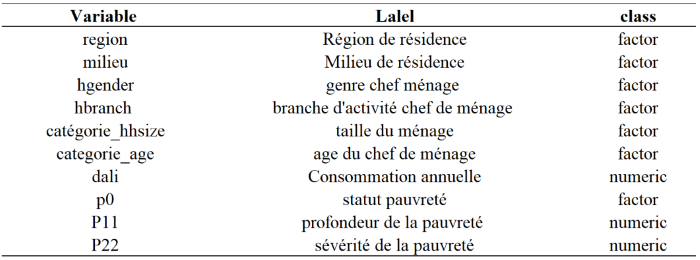

# II Tableau descriptif univarié

## II-1 Thémes du tableaux

gtsummary fournit plusieurs fonctions préfixées **theme_gtsummary()** permettent de modifier l’affichage par défaut des tableaux. Parmis les Exemples de fonctions nous avons: La fonction **theme_gtsummary_language**(Permets de modifier la langue utlisés dans le tableaux), La fonction **theme_gtsummary_journal**(Pour définir un thème prédéfini), La fonction **reset_gtsummary_theme**(Pour effacer tous les thémes précédemment définis)

```r
#Ramener le format du tableau en français
theme_gtsummary_language(language = "fr", decimal.mark = ",",
                         big.mark = " ")
```

## II-2 La fonction tbl_summary

La fonction au coeur du package **gtsummary** se nomme **tbl_summary()**.Elle produit un tableau qui s’affiche dans l’onglet “Viewer”. On lui passe en entrée un tableaux de données (data.frame) et par défaut toutes les variables sont résumé (base %>%tbl_summary())

La fonction *tbl_summary* permet d’obtenir la statistique descriptive ou tri à plat des variables, c’est-à-dire obtenir la moyenne, l’écart-type, intervalle interquartile, etc.Elle prend au minimum une base de données. Dans ce cas, elle affiche des statistiques descriptives pour chaque variable.

### II-2-1 Sélection des variables (include)

La paramètre include permets de spécifier les variables à inclure dans le tableau (et leur ordre). On peut lui passer un vecteur de noms de variables, ou bien utiliser des sélecteurs tidyselect (utiliser c() si plusieurs sélecteurs).

Par exemple, le tableau suivant nous donne des statistiques descriptives sur les variables **milieu**, **Niveau d’éducation du chef du ménage**, la variable **genre du chef de ménage**

```r
# Appliquer la fonction tbl_summary() à l'ensemble de données 'basev'
basev %>%
  tbl_summary(include = c("milieu","hgender","heduc"),

  value = list( milieu ~ "Rural", hgender ~ "Masculin"),
  label = list(milieu ~ "Milieu Rural",hgender ~ "Genre Masculin"))
```

| **Caractéristique** | **N = 66 120**<sup>1</sup> |
| --- | --- |
| Milieu Rural | 32 798 (50%) |
| Genre Masculin | 51 644 (78%) |
| Education du CM |  |
| Aucun | 47 811 (72%) |
| Maternelle | 6 (<0,1%) |
| Primaire | 9 019 (14%) |
| Second. gl 1 | 4 178 (6,3%) |
| Second. tech. 1 | 405 (0,6%) |
| Second. gl 2 | 2 002 (3,0%) |
| Second. tech. 2 | 187 (0,3%) |
| Postsecondaire | 425 (0,6%) |
| Superieur | 2 087 (3,2%) |

<sup>1</sup> n (%)

Il important de souligner que les statistiques envoyées par défaut dépendent du type de la variable. Ainsi, pour les variables du type numérique, nous avons un format du type : mediane (intervalle interquartile). Toutefois, il est possible de paramétrer ces arguments par défauts.

### II-2-2 Etiquettes des variables

Pour modifier l’étiquettes associé à une certaine variable,on peut utliser l’option *label* de *tbl_summary* par exemple:

```r
# Résumé tabulaire des statistiques descriptives pour les variables

'milieu'#, hgender avec une étiquette personnalisée
```

```
## [1] "milieu"
```

```r
basev %>%
  tbl_summary(include = c("milieu","hgender", "hbranch"),label =
                list(milieu~"milieu de naissance du CM", hgender~"genre CM")  )
```

| **Caractéristique** | **N = 66 120**<sup>1</sup> |
| --- | --- |
| milieu de naissance du CM |  |
| Urbain | 33 322 (50%) |
| Rural | 32 798 (50%) |
| genre CM |  |
| Masculin | 51 644 (78%) |
| Féminin | 14 476 (22%) |
| Branche activite du CM |  |
| Agriculture | 15 199 (31%) |
| Elevage/peche | 3 371 (6,8%) |
| Indust. extr. | 494 (1,0%) |
| Autr. indust. | 4 187 (8,5%) |
| BTP | 2 510 (5,1%) |
| Commerce | 9 441 (19%) |
| Restaurant/Hotel | 431 (0,9%) |
| Trans./Comm. | 2 250 (4,6%) |
| Education/Sante | 2 894 (5,9%) |
| Services perso. | 6 561 (13%) |
| Aut. services | 2 004 (4,1%) |
| Manquant | 16 778 |

<sup>1</sup> n (%)

Il est également possible d’utliser la syntaxe *tidyselect* et les selecteurs de *tidyselect* comme *everythings*,*starts_with*,*contains* ou*all_of*.

```r
# Résumé tabulaire des statistiques descriptives pour toutes les variables de l'ensemble de données
'base' #avec une étiquette commune
```

```
## [1] "base"
```

```r
basev %>%
  tbl_summary(include = c("milieu","hgender","heduc"),label=everything()~"Etiquette")
```

| **Caractéristique** | **N = 66 120**<sup>1</sup> |
| --- | --- |
| Etiquette |  |
| Urbain | 33 322 (50%) |
| Rural | 32 798 (50%) |
| Etiquette |  |
| Masculin | 51 644 (78%) |
| Féminin | 14 476 (22%) |
| Etiquette |  |
| Aucun | 47 811 (72%) |
| Maternelle | 6 (<0,1%) |
| Primaire | 9 019 (14%) |
| Second. gl 1 | 4 178 (6,3%) |
| Second. tech. 1 | 405 (0,6%) |
| Second. gl 2 | 2 002 (3,0%) |
| Second. tech. 2 | 187 (0,3%) |
| Postsecondaire | 425 (0,6%) |
| Superieur | 2 087 (3,2%) |

<sup>1</sup> n (%)

## II-3 Statistiques à afficher

on peut définir une liste dans laquelle on indique des formules spécifient les types de statistiques descriptives à afficher pour les variables ,comme suit:

```r
# Générer un résumé tabulaire des statistiques
#descriptives pour les variables 'P1' et 'P22' de
#l'ensemble de données 'basev'
# Spécifier les statistiques à afficher pour les variables P11, P22
basev %>%
  tbl_summary(
    include = c(P11,P22,dali),  # Sélectionner la variable 'region'
    statistic = all_continuous() ~ "Moy.:{mean}[min-max:{min}-{max}]",
    #Spécifier les statistiques à afficher
 label = list(P11~"pronfondeur de la pauvreté",P22~"Sévérité de la
              pauvreté", dali~"Consommation annuelle") )
```

| **Caractéristique** | **N = 66 120**<sup>1</sup> |
| --- | --- |
| pronfondeur de la pauvreté | Moy.:0,12[min-max:0,00-0,81] |
| Sévérité de la pauvreté | Moy.:0,05[min-max:0,00-0,65] |
| Consommation annuelle | Moy.:2 513 834[min-max:113 187-31 295 272] |

<sup>1</sup> Moy.:Moyenne[min-max:Minimum-Maximum]

```r
# Générer un résumé tabulaire des statistiques descriptives pour les
#variables 'region' et 'milieu' de l'ensemble de données 'base'
# Trier les modalités des variables catégorielles par fréquence,
#de la plus
#fréquente à la moins fréquente
basev %>%
  tbl_summary(
    include = c(region, milieu),
    # Sélectionner les variables region et milieu
    sort = all_categorical() ~ "frequency"
    # Trier les modalités par fréquence pour les variables catégorielles
  )
```

| **Caractéristique** | **N = 66 120**<sup>1</sup> |
| --- | --- |
| Region residence |  |
| DAKAR | 7 116 (11%) |
| DIOURBEL | 5 473 (8,3%) |
| THIES | 5 457 (8,3%) |
| KAOLACK | 5 374 (8,1%) |
| SAINT-LOUIS | 4 998 (7,6%) |
| LOUGA | 4 729 (7,2%) |
| TAMBACOUNDA | 4 397 (6,7%) |
| KAFFRINE | 4 367 (6,6%) |
| SEDHIOU | 4 329 (6,5%) |
| MATAM | 4 197 (6,3%) |
| KOLDA | 4 085 (6,2%) |
| FATICK | 4 084 (6,2%) |
| KEDOUGOU | 3 953 (6,0%) |
| ZIGUINCHOR | 3 561 (5,4%) |
| Milieu residence |  |
| Urbain | 33 322 (50%) |
| Rural | 32 798 (50%) |

<sup>1</sup> n (%)

La fonction **add_n()** est utilisée pour ajouter une colonne au résumé tabulaire qui indique le nombre d’observations non manquantes pour chaque variable par défaut.

```r
# Générer un résumé tabulaire des statistiques descriptives pour les
#variables 'region' et 'milieu' de l'ensemble de données 'base'
# Ajouter une colonne avec le nombre d'observations non manquantes par défaut
basev %>%
  tbl_summary(include = c(region, milieu)) %>%
  add_n()
```

| **Caractéristique** | **N** | **N = 66 120**<sup>1</sup> |
| --- | --- | --- |
| Region residence | 66 120 |  |
| DAKAR |  | 7 116 (11%) |
| ZIGUINCHOR |  | 3 561 (5,4%) |
| DIOURBEL |  | 5 473 (8,3%) |
| SAINT-LOUIS |  | 4 998 (7,6%) |
| TAMBACOUNDA |  | 4 397 (6,7%) |
| KAOLACK |  | 5 374 (8,1%) |
| THIES |  | 5 457 (8,3%) |
| LOUGA |  | 4 729 (7,2%) |
| FATICK |  | 4 084 (6,2%) |
| KOLDA |  | 4 085 (6,2%) |
| MATAM |  | 4 197 (6,3%) |
| KAFFRINE |  | 4 367 (6,6%) |
| KEDOUGOU |  | 3 953 (6,0%) |
| SEDHIOU |  | 4 329 (6,5%) |
| Milieu residence | 66 120 |  |
| Urbain |  | 33 322 (50%) |
| Rural |  | 32 798 (50%) |

<sup>1</sup> n (%)

```r
# Ajouter une colonne avec le nombre d'observations non
#manquantes par défaut
```

## II-4 Intervalle de confiance(add_ci)

l’argument **add_ci()** est utilisée pour ajouter les intervalles de confiance au résumé tabulaire.

```r
# Générer un résumé tabulaire des statistiques descriptives pour les
#variables 'region' et 'milieu' de l'ensemble de données 'basev'
# Ajouter une colonne avec le nombre d'observations non manquantes par défaut
basev %>%
  tbl_summary(include = c(region, milieu)) %>%
  add_ci() # Ajouter les intervalles de confiance
```

| **Caractéristique** | **N = 66 120**<sup>1</sup> | **95% CI**<sup>2</sup> |
| --- | --- | --- |
| Region residence |  |  |
| DAKAR | 7 116 (11%) | 11%, 11% |
| ZIGUINCHOR | 3 561 (5,4%) | 5,2%, 5,6% |
| DIOURBEL | 5 473 (8,3%) | 8,1%, 8,5% |
| SAINT-LOUIS | 4 998 (7,6%) | 7,4%, 7,8% |
| TAMBACOUNDA | 4 397 (6,7%) | 6,5%, 6,8% |
| KAOLACK | 5 374 (8,1%) | 7,9%, 8,3% |
| THIES | 5 457 (8,3%) | 8,0%, 8,5% |
| LOUGA | 4 729 (7,2%) | 7,0%, 7,4% |
| FATICK | 4 084 (6,2%) | 6,0%, 6,4% |
| KOLDA | 4 085 (6,2%) | 6,0%, 6,4% |
| MATAM | 4 197 (6,3%) | 6,2%, 6,5% |
| KAFFRINE | 4 367 (6,6%) | 6,4%, 6,8% |
| KEDOUGOU | 3 953 (6,0%) | 5,8%, 6,2% |
| SEDHIOU | 4 329 (6,5%) | 6,4%, 6,7% |
| Milieu residence |  |  |
| Urbain | 33 322 (50%) | 50%, 51% |
| Rural | 32 798 (50%) | 49%, 50% |

<sup>1</sup> n (%)  
<sup>2</sup> IC = intervalle de confiance

## II-5 Données manquantes

Le package gtsummary offre plusieurs paramétres pour manipuler les données manquantes ,presenter ci-dessous:

```r
basev %>%
  tbl_summary(
    # Inclure les colonnes "milieu" et "region" dans le résumé
    include = c("milieu", "region"),
    # Indiquer qu'il faut toujours afficher le nombre
    #d'observations manquantes
    missing = "always",
    # Personnaliser le texte affiché pour les observations manquantes
    missing_text = "Nbre observations manquantes"
  )
```

| **Caractéristique** | **N = 66 120**<sup>1</sup> |
| --- | --- |
| Milieu residence |  |
| Urbain | 33 322 (50%) |
| Rural | 32 798 (50%) |
| Nbre observations manquantes | 0 |
| Region residence |  |
| DAKAR | 7 116 (11%) |
| ZIGUINCHOR | 3 561 (5,4%) |
| DIOURBEL | 5 473 (8,3%) |
| SAINT-LOUIS | 4 998 (7,6%) |
| TAMBACOUNDA | 4 397 (6,7%) |
| KAOLACK | 5 374 (8,1%) |
| THIES | 5 457 (8,3%) |
| LOUGA | 4 729 (7,2%) |
| FATICK | 4 084 (6,2%) |
| KOLDA | 4 085 (6,2%) |
| MATAM | 4 197 (6,3%) |
| KAFFRINE | 4 367 (6,6%) |
| KEDOUGOU | 3 953 (6,0%) |
| SEDHIOU | 4 329 (6,5%) |
| Nbre observations manquantes | 0 |

<sup>1</sup> n (%)

## II-6 Statistique personnalisée avec tbl_continous et tbl_custom_summary

### II-6-1 tbl_contunous()

Par exemple, pour afficher la consommation moyenne moyen de plusieurs sous-groupes :

```r
# Afficher pour chaque milieu la moyenne dali
basev%>%
  tbl_continuous(
    variable = dali,
    statistic = ~ "{mean}",
    include = milieu
  )
```

| **Caractéristique** | **N = 66 120**<sup>1</sup> |
| --- | --- |
| Milieu residence |  |
| Urbain | 2 854 149 |
| Rural | 2 168 082 |

<sup>1</sup> Conso annuelle alim. menage: Moyenne

### II-6-2 tbl_custom_summary()

La fonction tbl_custom_summary permets encore plus de personnalisation que tbl_continuous .

On doit fournir via stat_fns une fonction personnalisée qui va recevoir un sous tableau de données , contenant toutes les variables du fichier, et qui renverra des statistiques personnalisées que l’on affichera avec statistic . La fonction peut-être différente pour chaque variable. Il est également possible d’utiliser quelques fonctions dédiées fournies directement par gtsummary.

```r
# afficher pour chaque milieu, le genre, la taille
#du ménage la proportion de pauvreté
basev%>%
  tbl_custom_summary(
  include = c(milieu, hgender, categorie_hhsize),
  stat_fns = ~proportion_summary(variable="p0",value="pauvre"),
  statistic = ~"{prop}"
)
```

| **Caractéristique** | **N = 66 120**<sup>1</sup> |
| --- | --- |
| Milieu residence |  |
| Urbain | 0,29 |
| Rural | 0,55 |
| Genre du chef de ménage |  |
| Masculin | 0,47 |
| Féminin | 0,26 |
| Taille du ménage |  |
| Moins de 4 persones | 0,06 |
| 5 à 9 persones | 0,29 |
| 10 à 14 persones | 0,43 |
| 15 à 19 persones | 0,52 |
| 20 persones et plus | 0,70 |

<sup>1</sup> prop

## II-7 Application

```r
#Application 1
basev %>%
  tbl_summary(include = c(milieu,hgender,dali),
              missing = "always",
              missing_text = "Nbre observations manquantes",
              sort = all_categorical() ~ "frequency",
              value = list( milieu ~ "Rural", hgender ~ "Masculin"),
              label = list(milieu ~ "Milieu Rural",
                           hgender ~ "Genre Masculin",
                           dali~"Consommation annuelle"),
              statistic = all_continuous() ~
                "Moy.:{mean}[min-max:{min}-{max}]",) %>%
              add_n()  %>%
              add_ci()
```

| **Caractéristique** | **N** | **N = 66 120**<sup>1</sup> | **95% CI**<sup>2</sup> |
| --- | --- | --- | --- |
| Milieu Rural | 66 120 | 32 798 (50%) | 49%, 50% |
| Nbre observations manquantes |  | 0 |  |
| Genre Masculin | 66 120 | 51 644 (78%) | 78%, 78% |
| Nbre observations manquantes |  | 0 |  |
| Consommation annuelle | 66 120 | Moy.:2 513 834[min-max:113 187-31 295 272] | 2 500 157, 2 527 511 |
| Nbre observations manquantes |  | 0 |  |

<sup>1</sup> n (%); Moy.:Moyenne[min-max:Minimum-Maximum]  
<sup>2</sup> IC = intervalle de confiance

```r
#Application 2
## Créer un dataframe pour les années passées
my_data <- data.frame(
  milieu = c("Urbain", "Rural"),
  taux = c(0.22, 0.58)
)

## Traduire le dataframe en tableau gt
pauvreté2011<-my_data%>%
  mutate(milieu=factor(milieu, levels=c("Urbain","Rural")))%>%
  tbl_custom_summary(
  include = c(milieu), label = milieu~ "Milieu residence",
  stat_fns = ~continuous_summary("taux"),
  statistic = ~"{mean}",
  digits = ~ list(
      function(x) {
        style_percent(x, digits = 1)
      },
      0, 0, style_percent, style_percent
    ),
  overall_row = TRUE,  ##
  overall_row_last = TRUE
)%>%
  modify_header(stat_0~"**%**")%>%
  modify_footnote(everything()~NA)

## Le tableau de la proportion de pauvres
pauvreté2018<-basev%>%
  tbl_custom_summary(
  include = c(milieu),
  stat_fns = ~proportion_summary(variable="p0",value="pauvre"),
  statistic = ~"{prop}",
  digits = ~ list(
      function(x) {
        style_percent(x, digits = 1)
      },
      0, 0, style_percent, style_percent
    ),
  overall_row = TRUE,
  overall_row_last = TRUE
)%>%
  modify_header(stat_0~"**%**")%>%
  modify_footnote(everything()~NA)

## Merger les deux tableaux
tbl_merge(list(pauvreté2011,pauvreté2018),tab_spanner =
            c("Taux de Pauvreté 2011",
              "Taux de Pauvreté 2018/2019"))%>%
  as_gt()%>%
  gt::tab_header(
    title=gt::md("**Taux de pauvreté selon le milieu**"))%>%
  gt::tab_source_note("EHCVM, calculs de l'auteur")
```

**Taux de pauvreté selon le milieu**

| **Caractéristique** | Taux de Pauvreté 2011 **%** | Taux de Pauvreté 2018/2019 **%** |
| --- | --- | --- |
| Milieu residence |  |  |
| Urbain | 22,0 | 29,4 |
| Rural | 58,0 | 55,2 |
| Total | 40,0 | 42,2 |

EHCVM, calculs de l'auteur

```r
# Application 3
## Pauvreté selon le niveau d'éducation
### Tableau de l'incidence de pauvreté
incidence<-basev%>%
  tbl_custom_summary(
  include = c(heduc),
  stat_fns = ~proportion_summary(variable="p0",value="pauvre"),
  statistic = ~"{prop}",
  digits = ~ list(
      function(x) {
        style_percent(x, digits = 1)
      },
      0, 0, style_percent, style_percent
    )
)%>%
  bold_labels()%>%
  italicize_levels()%>%
  modify_header(stat_0~"**%**")%>%
  modify_footnote(everything()~NA)
### Le tableau de la profonduer de pauvreté
profondeur<-basev%>%
  tbl_custom_summary(
  include = c(heduc),
  stat_fns = ~continuous_summary("P11"),
  statistic = ~"{mean}",
  digits = ~ list(
      function(x) {
        style_percent(x, digits = 1)
      },
      0, 0, style_percent, style_percent
    )
)%>%
  bold_labels()%>%
  italicize_levels()%>%
  modify_header(stat_0~"**%**")%>%
  modify_footnote(everything()~NA)
### Le tableau de la sévérité de pauvreté
severite<-basev%>%
  tbl_custom_summary(
  include = c(heduc),
  stat_fns = ~continuous_summary("P22"),
  statistic = ~"{mean}",
  digits = ~ list(
      function(x) {
        style_percent(x, digits = 1)
      },
      0, 0, style_percent, style_percent
    )
)%>%
  bold_labels()%>%
  italicize_levels()%>%
  modify_header(stat_0~"**%**")%>%
  modify_footnote(everything()~NA)
###Merger les trois tableaux
tbl_merge(list(incidence,profondeur,severite),tab_spanner =
            c("Incidence","profondeur","sévérité"))%>%
  as_gt()%>%
  gt::tab_header(
    title=gt::md("**Indicateur de pauvreté selon la niveau
                 d'éducation**"))%>%
  gt::tab_source_note("EHCVM, calculs de l'auteur")
```

**Indicateur de pauvreté selon la niveau d’éducation**

| **Caractéristique** | Incidence **%** | profondeur **%** | sévérité **%** |
| --- | --- | --- | --- |
| Education du CM |  |  |  |
| Aucun | 49,0 | 14,4 | 5,83 |
| Maternelle | 0 | 0 | 0 |
| Primaire | 31,1 | 7,59 | 2,66 |
| Second. gl 1 | 24,8 | 6,43 | 2,34 |
| Second. tech. 1 | 35,3 | 9,18 | 3,16 |
| Second. gl 2 | 13,1 | 3,24 | 1,03 |
| Second. tech. 2 | 24,1 | 1,92 | 0,15 |
| Postsecondaire | 0 | 0 | 0 |
| Superieur | 7,19 | 0,85 | 0,27 |

EHCVM, calculs de l'auteur

```r
# Application 4
## Pauvreté selon la région
### Tableau de l'incidence de pauvreté
incidence<-basev%>%
  tbl_custom_summary(
  include = c(region),
  stat_fns = ~proportion_summary(variable="p0",value="pauvre"),
  statistic = ~"{prop}",
  digits = ~ list(
      function(x) {
        style_percent(x, digits = 1)
        # Metrre les proportion en format %
      },
      0, 0, style_percent, style_percent
    )
)%>%
  bold_labels()%>%
  italicize_levels()%>%
  modify_header(stat_0~"**%**")%>%
  modify_footnote(everything()~NA)
### Le tableau de la profonduer de pauvreté
profondeur<-basev%>%
  tbl_custom_summary(
  include = c(region),
  stat_fns = ~continuous_summary("P11"),
  statistic = ~"{mean}",
  digits = ~ list(
      function(x) {
        style_percent(x, digits = 1)
        # Metrre les proportion en format %
      },
      0, 0, style_percent, style_percent
    )
)%>%
  bold_labels()%>%
  italicize_levels()%>%
  modify_header(stat_0~"**%**")%>%
  modify_footnote(everything()~NA)
### Le tableau de la sévérité de pauvreté
severite<-basev%>%
  tbl_custom_summary(
  include = c(region),
  stat_fns = ~continuous_summary("P22"),
  statistic = ~"{mean}",
  digits = ~ list(
      function(x) {
        style_percent(x, digits = 1)
        # Metrre les proportion en format % à un
        #chiffre aprés la virgule
      },
      0, 0, style_percent, style_percent
    )
)%>%
  bold_labels()%>%
  italicize_levels()%>%
  modify_header(stat_0~"**%**")%>%
  modify_footnote(everything()~NA)
###Merger les trois tableaux
tbl_merge(list(incidence,profondeur,severite),tab_spanner =
            c("Incidence","profondeur","sévérité"))%>%
  as_gt()%>%
  gt::tab_header(
    title=gt::md("**Indicateur de pauvreté selon le niveau
                 d'éducation**"))%>%
  gt::tab_source_note("EHCVM, calculs de l'auteur")
```

| **Caractéristique** | Incidence **%** | profondeur **%** | sévérité **%** |
| --- | --- | --- | --- |
| Region residence |  |  |  |
| DAKAR | 9,74 | 1,43 | 0,35 |
| ZIGUINCHOR | 47,9 | 14,3 | 5,90 |
| DIOURBEL | 43,9 | 10,3 | 3,41 |
| SAINT-LOUIS | 39,4 | 11,1 | 4,32 |
| TAMBACOUNDA | 58,7 | 18,0 | 7,43 |
| KAOLACK | 35,9 | 10,3 | 4,15 |
| THIES | 34,9 | 7,96 | 2,59 |
| LOUGA | 36,3 | 9,40 | 3,37 |
| FATICK | 42,0 | 11,4 | 4,08 |
| KOLDA | 54,8 | 15,7 | 6,12 |
| MATAM | 48,9 | 15,1 | 6,46 |
| KAFFRINE | 48,2 | 15,2 | 6,61 |
| KEDOUGOU | 55,8 | 19,0 | 8,82 |
| SEDHIOU | 61,7 | 19,6 | 8,13 |

EHCVM, calculs de l'auteur

# III Tableaux croisés

Il s’agit dans cette partie de savoir comment ventiler les fréquences de deux variables catégorielles dans un tableau, comment faire sortir les fréquences et éventuellement utliser quelques fonctions du package **gtsummary** telles que les thèmes…

## III-1 Tableaux croisés avec tbl_summary et tbl_custom_summary

Nous allons à présent utiliser les fonctions tbl_summary et tbl_custom_summary combinées avec **by**. Il s’agit dans cette partie d’analyser la pauvreté en fonction du genre du chef du ménage, de la région, du milieu de résidence … Il est imporatant de savoir que le regroupement se fait par une variable catégorielle sinon, le regroupement n’aura pas de sens.

```r
basev %>%
  tbl_summary(include = c(P11, P22),
    by = hgender,
    label = list(P11 ~ "Profondeur de pauvreté",
                 P22 ~ "Sévérité de la pauvreté"),
    statistic = list(c(P11, P22)~ "{mean}")
)%>%  add_difference() %>%
  as_gt()%>%
  gt::tab_header(
    title=gt::md("**Profondeur et sévérité de la
                 pauvreté selon le sexe CM**"))%>%
  gt::tab_source_note("EHCVM, calculs de l'auteur")
```

**Profondeur et sévérité de la pauvreté selon le sexe CM**

| **Caractéristique** | **Masculin**, N = 51 644<sup>1</sup> | **Féminin**, N = 14 476<sup>1</sup> | **Difference**<sup>2</sup> | **95% IC**<sup>2,3</sup> | **p-valeur**<sup>2</sup> |
| --- | --- | --- | --- | --- | --- |
| Profondeur de pauvreté | 0,14 | 0,06 | 0,07 | 0,07 – 0,08 | <0,001 |
| Sévérité de la pauvreté | 0,05 | 0,02 | 0,03 | 0,03 – 0,03 | <0,001 |

EHCVM, calculs de l'auteur  
<sup>1</sup> Moyenne  
<sup>2</sup> test de Student  
<sup>3</sup> IC = intervalle de confiance

Analyse de la pauvreté selon l’âge et le genre du chef de ménage

```r
basev %>%
  tbl_custom_summary(
    include = "categorie_age",
    label = categorie_age~ "Classe d'âge",
    by = "hgender",
    stat_fns = ~ proportion_summary("p0", "pauvre"),
    statistic = ~"{prop}% ",
    digits = ~ list(
      function(x) {
        style_percent(x, digits = 1)
      },
      0, 0, style_percent, style_percent
    ),
    overall_row = TRUE,
    overall_row_last = TRUE
  ) %>%
  bold_labels() %>%
  modify_footnote(
    update = all_stat_cols() ~ ""
  )%>%
  as_gt()%>%
  gt::tab_header(
    title=gt::md("**Taux de pauvreté selon l'âge et le sexe**"))%>%
  gt::tab_source_note("EHCVM, calculs de l'auteur")
```

**Taux de pauvreté selon l’âge et le sexe**

| **Caractéristique** | **Masculin**, N = 51 644<sup>1</sup> | **Féminin**, N = 14 476<sup>1</sup> |
| --- | --- | --- |
| Classe d'âge |  |  |
| Moins de 24 ans | 50,0% | 28,5% |
| 25 à 39 ans | 41,9% | 21,6% |
| 40 à 49 ans | 41,2% | 19,3% |
| 50 à 59 ans | 40,5% | 22,5% |
| 60 ans et plus | 40,3% | 19,9% |
| Manquant | 4 | 3 |
| Total | 46,8% | 25,8% |

EHCVM, calculs de l'auteur  
<sup>1</sup>

## III-2 Tableaux croisés avec tbl_cross

```r
basev %>% tbl_cross(row = categorie_age,
                    col = categorie_hhsize,
                    percent = "cell",
                    label = categorie_age ~ "Age CM" ) %>%

  as_gt()%>%
  gt::tab_header(
    title=gt::md("**Répartition des ménages
                 selon la taille et l'age CM**"))%>%
  gt::tab_source_note("EHCVM, calculs de l'auteur")
```

**Répartition des ménages selon la taille et l’age CM**

|  | Taille du ménage Moins de 4 persones | Taille du ménage 5 à 9 persones | Taille du ménage 10 à 14 persones | Taille du ménage 15 à 19 persones | Taille du ménage 20 persones et plus | Total |  |
| --- | --- | --- | --- | --- | --- | --- | --- |
| Age CM |  |  |  |  |  |  |  |
| Moins de 24 ans | 1 493 (2,3%) | 13 471 (20%) | 12 704 (19%) | 7 235 (11%) | 7 091 (11%) | 41 994 (64%) |  |
| 25 à 39 ans | 847 (1,3%) | 3 605 (5,5%) | 3 249 (4,9%) | 1 801 (2,7%) | 1 757 (2,7%) | 11 259 (17%) |  |
| 40 à 49 ans | 425 (0,6%) | 1 863 (2,8%) | 1 369 (2,1%) | 721 (1,1%) | 710 (1,1%) | 5 088 (7,7%) |  |
| 50 à 59 ans | 335 (0,5%) | 1 352 (2,0%) | 1 002 (1,5%) | 488 (0,7%) | 434 (0,7%) | 3 611 (5,5%) |  |
| 60 ans et plus | 376 (0,6%) | 1 412 (2,1%) | 1 213 (1,8%) | 621 (0,9%) | 539 (0,8%) | 4 161 (6,3%) |  |
| Unknown | 0 (0%) | 2 (<0,1%) | 3 (<0,1%) | 1 (<0,1%) | 1 (<0,1%) | 7 (<0,1%) |  |
| Total | 3 476 (5,3%) | 21 705 (33%) | 19 540 (30%) | 10 867 (16%) | 10 532 (16%) | 66 120 (100%) |  |

EHCVM, calculs de l'auteur

# Iv Régression logistique binaire

La régression logistique binaire (également appelé modèle logit) est souvent utilisé pour la classification et l’analyse prédictive. La régression logistique estime la probabilité qu’un événement se produise, tel que voter ou ne pas voter, sur la base d’un ensemble de données donné de variables indépendantes. Comme le résultat est une probabilité, la variable dépendante est bornée entre 0 et 1.

## Iv-1 Régression logistique avec tbl_regression

```r
# faire un modèle de régréssion la variable dépendante p0(pauvreté)
#les variables indépendantes: milieu, categorie_hsize
mod<-glm(p0~milieu + hgender + categorie_hhsize,
         data = basev, family = binomial
         )
mod%>%tbl_regression()
```

| **Caractéristique** | **log(OR)**<sup>1</sup> | **95% IC**<sup>1</sup> | **p-valeur** |
| --- | --- | --- | --- |
| Milieu residence |  |  |  |
| Urbain | — | — |  |
| Rural | 0,98 | 0,95 – 1,0 | <0,001 |
| Genre du chef de ménage |  |  |  |
| Masculin | — | — |  |
| Féminin | -0,48 | -0,53 – -0,44 | <0,001 |
| Taille du ménage |  |  |  |
| Moins de 4 persones | — | — |  |
| 5 à 9 persones | 1,8 | 1,6 – 1,9 | <0,001 |
| 10 à 14 persones | 2,4 | 2,2 – 2,5 | <0,001 |
| 15 à 19 persones | 2,7 | 2,5 – 2,8 | <0,001 |
| 20 persones et plus | 3,4 | 3,3 – 3,6 | <0,001 |

<sup>1</sup> OR = rapport de cotes, IC = intervalle de confiance

### Iv-1-1 Avec le paramètre include

Le paramètre include permet de choisir les variables à afficher

```r
#
mod%>%tbl_regression(include=c(milieu))
```

| **Caractéristique** | **log(OR)**<sup>1</sup> | **95% IC**<sup>1</sup> | **p-valeur** |
| --- | --- | --- | --- |
| Milieu residence |  |  |  |
| Urbain | — | — |  |
| Rural | 0,98 | 0,95 – 1,0 | <0,001 |

<sup>1</sup> OR = rapport de cotes, IC = intervalle de confiance

### Iv-1-2 Exponentiation des coefficients

Pour une regression logistique il est d’usage d’utiliser d’afficher l’exponentiation des coefficients, ce que l’on peut faire en indiquant **exponentiate=True**

```r
mod%>%tbl_regression(exponentiate = TRUE)
```

| **Caractéristique** | **OR**<sup>1</sup> | **95% IC**<sup>1</sup> | **p-valeur** |
| --- | --- | --- | --- |
| Milieu residence |  |  |  |
| Urbain | — | — |  |
| Rural | 2,67 | 2,58 – 2,76 | <0,001 |
| Genre du chef de ménage |  |  |  |
| Masculin | — | — |  |
| Féminin | 0,62 | 0,59 – 0,64 | <0,001 |
| Taille du ménage |  |  |  |
| Moins de 4 persones | — | — |  |
| 5 à 9 persones | 5,77 | 4,99 – 6,71 | <0,001 |
| 10 à 14 persones | 10,8 | 9,36 – 12,6 | <0,001 |
| 15 à 19 persones | 14,5 | 12,5 – 16,9 | <0,001 |
| 20 persones et plus | 31,1 | 26,8 – 36,2 | <0,001 |

<sup>1</sup> OR = rapport de cotes, IC = intervalle de confiance

### Iv-1-3 Afficher les étoiles de significations

La fonction **add_significance_stars** ajoute des étoiles de significativité à coté des coefficients. Les options hide_ci, hide_p, hide_se permettent de masquer/afficher les intervalles de confiances, les pvaleurs et les écarts types.

```r
mod%>%tbl_regression()%>%
  add_significance_stars(hide_ci = FALSE,
                         hide_p = FALSE, hide_se = TRUE)
```

| **Caractéristique** | **log(OR)**<sup>1,2</sup> | **95% IC**<sup>2</sup> | **p-valeur** |
| --- | --- | --- | --- |
| Milieu residence |  |  |  |
| Urbain | — | — |  |
| Rural | 0,98*** | 0,95 – 1,0 | <0,001 |
| Genre du chef de ménage |  |  |  |
| Masculin | — | — |  |
| Féminin | -0,48*** | -0,53 – -0,44 | <0,001 |
| Taille du ménage |  |  |  |
| Moins de 4 persones | — | — |  |
| 5 à 9 persones | 1,8*** | 1,6 – 1,9 | <0,001 |
| 10 à 14 persones | 2,4*** | 2,2 – 2,5 | <0,001 |
| 15 à 19 persones | 2,7*** | 2,5 – 2,8 | <0,001 |
| 20 persones et plus | 3,4*** | 3,3 – 3,6 | <0,001 |

<sup>1</sup> *p<0.05; **p<0.01; ***p<0.001  
<sup>2</sup> OR = rapport de cotes, IC = intervalle de confiance

## Iv-2 Régression univariée multiple avec tbl_uvregression

```r
tbl_uni <- tbl_uvregression(
  basev%>%select(p0,milieu, hgender,categorie_hhsize),
  method = glm,
  y=p0,
  method.args = list(family=binomial),
  exponentiate = TRUE,
  hide_n = TRUE)
tbl_uni
```

| **Caractéristique** | **OR**<sup>1</sup> | **95% IC**<sup>1</sup> | **p-valeur** |
| --- | --- | --- | --- |
| Milieu residence |  |  |  |
| Urbain | — | — |  |
| Rural | 2,96 | 2,87 – 3,06 | <0,001 |
| Genre du chef de ménage |  |  |  |
| Masculin | — | — |  |
| Féminin | 0,40 | 0,38 – 0,41 | <0,001 |
| Taille du ménage |  |  |  |
| Moins de 4 persones | — | — |  |
| 5 à 9 persones | 6,66 | 5,77 – 7,73 | <0,001 |
| 10 à 14 persones | 12,7 | 11,0 – 14,7 | <0,001 |
| 15 à 19 persones | 17,8 | 15,4 – 20,7 | <0,001 |
| 20 persones et plus | 38,4 | 33,2 – 44,8 | <0,001 |

<sup>1</sup> OR = rapport de cotes, IC = intervalle de confiance

## Iv-3 Application: regression binomiale

```r
mod <- glm(p0~milieu + hgender + categorie_hhsize,
         data = basev, family = binomial)

tbl_mod_b <- mod%>%
  tbl_regression(exponentiate = TRUE,
                 intercept = TRUE,
                estimate_fun = scales::label_number(accuracy=.001,
                                              decimal.mark ="," ),
                    pvalue_fun= scales::label_pvalue(accuracy=.001,
                                            decimal.mark=","))%>%
  modify_header(c(label~"**Variables**",estimate~"**Odds
                  ratio**",std.error="**standart error**",
                  p.value ~ "*Test de comparaison* (p-valeur)"))%>%
  modify_footnote(everything()~NA, abbreviation = TRUE)%>%
  add_significance_stars(hide_ci = TRUE, hide_p = FALSE, hide_se = FALSE)%>%
  bold_labels()%>%
  italicize_levels()
```

```r
tbl_desc<-basev%>%tbl_custom_summary(
  include = c(milieu, hgender, categorie_hhsize),
  stat_fns = ~proportion_summary(variable="p0",value="pauvre"),
  statistic = ~"{prop}",
  digits = ~ list(
      function(x) {
        style_percent(x, digits = 1)
      },
      0, 0, style_percent, style_percent
      # Mettre les proportion en format %
    )
)%>%
  modify_header(stat_0~"**proportion**")%>%
  modify_footnote(everything()~NA)
```

```r
tbl_merge(list(tbl_desc,tbl_mod_b),tab_spanner = c("**Statistique
                                                   descriptive**","**Modèle logit**"))%>%
  as_gt()%>%
  gt::tab_header(
    title=gt::md("**Tableau: Resultat du modèle logistique**"))%>%
  gt::tab_source_note("EHCVM, calculs de l'auteur")
```

**Tableau: Resultat du modèle logistique**

| **Caractéristique** | **Statistique descriptive** **proportion** | **Modèle logit** **Odds ratio**<sup>1</sup> | **Modèle logit** **standart error** | **Modèle logit** *Test de comparaison* (p-valeur) |
| --- | --- | --- | --- | --- |
| Milieu residence |  |  |  |  |
| Urbain | 29,4 | — | — |  |
| Rural | 55,2 | 2,671*** | 0,018 | <0,001 |
| Genre du chef de ménage |  |  |  |  |
| Masculin | 46,8 | — | — |  |
| Féminin | 25,8 | 0,616*** | 0,023 | <0,001 |
| Taille du ménage |  |  |  |  |
| Moins de 4 persones | 5,70 | — | — |  |
| 5 à 9 persones | 28,7 | 5,771*** | 0,075 | <0,001 |
| 10 à 14 persones | 43,3 | 10,814*** | 0,075 | <0,001 |
| 15 à 19 persones | 51,8 | 14,509*** | 0,077 | <0,001 |
| 20 persones et plus | 69,9 | 31,058*** | 0,077 | <0,001 |
| (Intercept) |  | 0,047*** | 0,075 | <0,001 |

EHCVM, calculs de l'auteur  
<sup>1</sup> *p<0.05; **p<0.01; ***p<0.001

# V Résumé

Les fonctions les plus utilisées sont :

- **tbl_summary**

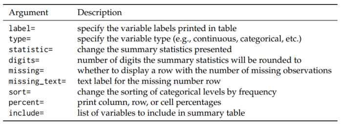

- **add…()**

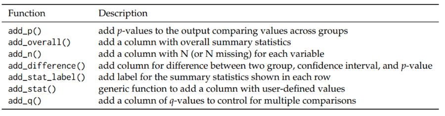

- **format tableau**

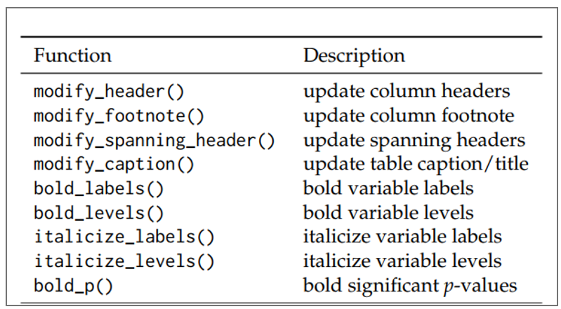

- **Exportation** : gtsave , flextable::save_as_docx Les principaux tableaux sortis sont dans le fichier **tableaux_** du dossier **output**. Vous pouvez vous y référer pour les tableaux débordant ou également au fichier html.

# VI Bibliographie et webographie

- *https://www.danieldsjoberg.com/gtsummary-weill-cornell-presentation/#59*
- *https://github.com/ddsjoberg/gtsummary*
- *https://www.danieldsjoberg.com/gtsummary/*
- *Reproducible Summary Tables with the gtsummary Package by Daniel D. Sjoberg, Karissa Whiting, Michael Curry, Jessica A. Lavery, Joseph Larmarange*
- *https://larmarange.github.io/analyse-R/gtsummary.html*